# Using Association Rules of the Online Retail Dataset

# 1 Load Data

We first want to load our datasets and prepare them for some simple association rules mining.

```r
tnx_data_tbl <- read_rds("data/retail_data_cleaned_tbl.rds")

tnx_data_tbl %>% glimpse()
```

```
## Rows: 1,021,424
## Columns: 23
## $ row_id            <chr> "ROW0000001", "ROW0000002", "ROW0000003", "ROW00000…
## $ excel_sheet       <chr> "Year 2009-2010", "Year 2009-2010", "Year 2009-2010…
## $ invoice_id        <chr> "489434", "489434", "489434", "489434", "489434", "…
## $ stock_code        <chr> "85048", "79323P", "79323W", "22041", "21232", "220…
## $ description       <chr> "15CM CHRISTMAS GLASS BALL 20 LIGHTS", "PINK CHERRY…
## $ quantity          <dbl> 12, 12, 12, 48, 24, 24, 24, 10, 12, 12, 24, 12, 10,…
## $ invoice_date      <date> 2009-12-01, 2009-12-01, 2009-12-01, 2009-12-01, 20…
## $ price             <dbl> 6.95, 6.75, 6.75, 2.10, 1.25, 1.65, 1.25, 5.95, 2.5…
## $ customer_id       <chr> "13085", "13085", "13085", "13085", "13085", "13085…
## $ country           <chr> "United Kingdom", "United Kingdom", "United Kingdom…
## $ stock_code_upr    <chr> "85048", "79323P", "79323W", "22041", "21232", "220…
## $ cancellation      <lgl> FALSE, FALSE, FALSE, FALSE, FALSE, FALSE, FALSE, FA…
## $ invoice_dttm      <dttm> 2009-12-01 07:45:00, 2009-12-01 07:45:00, 2009-12-…
## $ invoice_month     <chr> "December", "December", "December", "December", "De…
## $ invoice_dow       <chr> "Tuesday", "Tuesday", "Tuesday", "Tuesday", "Tuesda…
## $ invoice_dom       <chr> "01", "01", "01", "01", "01", "01", "01", "01", "01…
## $ invoice_hour      <chr> "07", "07", "07", "07", "07", "07", "07", "07", "07…
## $ invoice_minute    <chr> "45", "45", "45", "45", "45", "45", "45", "45", "45…
## $ invoice_woy       <chr> "49", "49", "49", "49", "49", "49", "49", "49", "49…
## $ invoice_ym        <chr> "200912", "200912", "200912", "200912", "200912", "…
## $ stock_value       <dbl> 83.40, 81.00, 81.00, 100.80, 30.00, 39.60, 30.00, 5…
## $ invoice_monthprop <dbl> 0.04347826, 0.04347826, 0.04347826, 0.04347826, 0.0…
## $ exclude           <lgl> FALSE, FALSE, FALSE, FALSE, FALSE, FALSE, FALSE, FA…
```

To use our rules mining we just need the invoice data and the stock code, so we can ignore the rest. Also, we ignore the issue of returns and just look at purchases.

```r
tnx_purchase_tbl <- tnx_data_tbl %>%
  filter(
    quantity > 0,
    exclude == FALSE
    ) %>%
  select(invoice_id, stock_code, customer_id, quantity, price, stock_value, description)

tnx_purchase_tbl %>% glimpse()
```

```
## Rows: 994,628
## Columns: 7
## $ invoice_id  <chr> "489434", "489434", "489434", "489434", "489434", "489434…
## $ stock_code  <chr> "85048", "79323P", "79323W", "22041", "21232", "22064", "…
## $ customer_id <chr> "13085", "13085", "13085", "13085", "13085", "13085", "13…
## $ quantity    <dbl> 12, 12, 12, 48, 24, 24, 24, 10, 12, 12, 24, 12, 10, 18, 3…
## $ price       <dbl> 6.95, 6.75, 6.75, 2.10, 1.25, 1.65, 1.25, 5.95, 2.55, 3.7…
## $ stock_value <dbl> 83.40, 81.00, 81.00, 100.80, 30.00, 39.60, 30.00, 59.50, …
## $ description <chr> "15CM CHRISTMAS GLASS BALL 20 LIGHTS", "PINK CHERRY LIGHT…
```

We now write this data out as a CSV so `arules` can read it in and process it.

```r
tnx_purchase_tbl %>% write_csv("data/tnx_purchase_tbl.csv")
```

# 2 Basket Analysis with Association Rules

We now want to do some basic basket analysis using association rules, which tries to determine which items get bought together, similar to taking a graph approachin many ways.

```r
basket_arules <- read.transactions(
    file   = "data/tnx_purchase_tbl.csv",
    format = "single",
    sep    = ",",
    header = TRUE,
    cols   = c("invoice_id", "stock_code")
    )

basket_arules %>% glimpse()
```

```
## Formal class 'transactions' [package "arules"] with 3 slots
##   ..@ data       :Formal class 'ngCMatrix' [package "Matrix"] with 5 slots
##   ..@ itemInfo   :'data.frame':  4965 obs. of  1 variable:
##   .. ..$ labels: chr [1:4965] "10002" "10002R" "10080" "10109" ...
##   ..@ itemsetInfo:'data.frame':  41410 obs. of  1 variable:
##   .. ..$ transactionID: chr [1:41410] "489434" "489435" "489436" "489437" ...
```

Now that we have this data we can look at some basic plots much like we produced before. For example, we can look at the relative frequency of the different items.

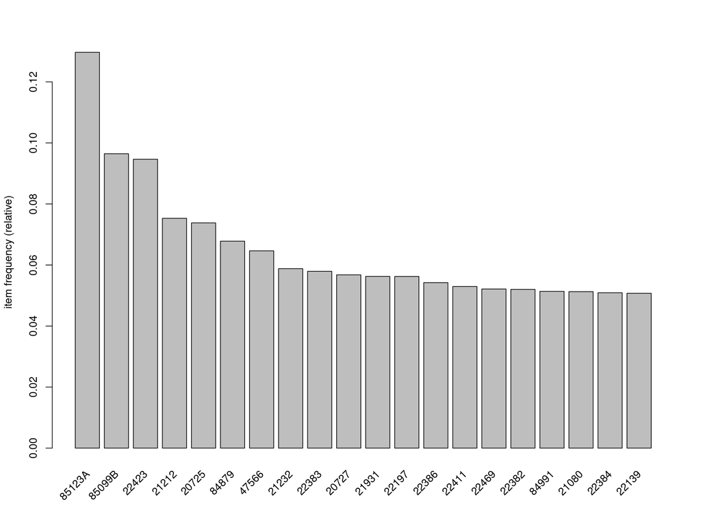

```r
itemFrequencyPlot(basket_arules, topN = 20)
```

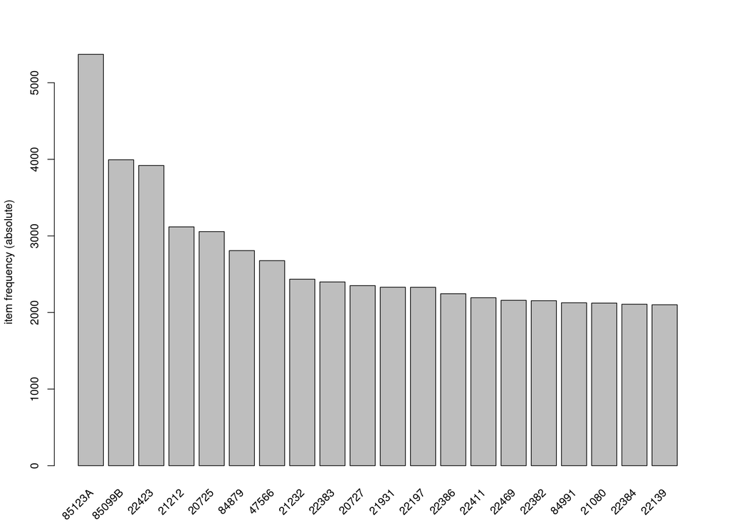

```r
itemFrequencyPlot(basket_arules, topN = 20, type = "absolute")
```

The stock codes do not mean a huge amount to us, so we also want to look at the description field for these items.

```r
freq_codes <- itemFrequency(basket_arules) %>%
  sort(decreasing = TRUE) %>%
  head(20) %>%
  names()

tnx_purchase_tbl %>%
  select(stock_code, description) %>%
  filter(stock_code %in% freq_codes) %>%
  distinct() %>%
  drop_na(description) %>%
  group_by(stock_code) %>%
  summarise(
    .groups = "drop",
    desc = str_c(description, collapse = " : ")
    ) %>%
  arrange(stock_code) %>%
  datatable()
```

|  | stock_code | desc |
| --- | --- | --- |
| 1 | 20725 | LUNCH BAG RED SPOTTY : LUNCH BAG RED RETROSPOT |
| 2 | 20727 | LUNCH BAG BLACK SKULL. |
| 3 | 21080 | SET/20 RED SPOTTY PAPER NAPKINS : SET/20 RED RETROSPOT PAPER NAPKINS |
| 4 | 21212 | PACK OF 72 RETRO SPOT CAKE CASES : PACK OF 72 RETROSPOT CAKE CASES |
| 5 | 21232 | STRAWBERRY CERAMIC TRINKET BOX : STRAWBERRY CERAMIC TRINKET POT |
| 6 | 21931 | JUMBO STORAGE BAG SUKI |
| 7 | 22139 | RETRO SPOT TEA SET CERAMIC 11 PC : 11 PC CERAMIC TEA SET POLKADOT : RETROSPOT TEA SET CERAMIC 11 PC : amazon |
| 8 | 22197 | POPCORN HOLDER , SMALL : SMALL POPCORN HOLDER : POPCORN HOLDER |
| 9 | 22382 | LUNCHBAG SPACEBOY DESIGN : LUNCH BAG SPACEBOY DESIGN |
| 10 | 22383 | LUNCHBAG SUKI DESIGN : LUNCH BAG SUKI DESIGN : LUNCH BAG SUKI DESIGN |

[output cut: 10 more lines]

## 2.1 Basic Concepts

The basic ideas of association rule mining and basket analysis draws on basic ideas from probability theory.

We speak in terms of the *itemset*: that is, a collection of one or more items that co-occur in a transaction.

For example, suppose we have a list of transactions as follows:

| ID | Items |
| --- | --- |
| 1 | milk, bread |
| 2 | bread, butter |
| 3 | beer |
| 4 | milk, bread, butter |
| 5 | bread, butter |

Using the above set of transactions, and itemset may be “milk” or “bread, butter”.

The support of an itemset $X$, $\text{Supp}(X)$, is defined as the proportion of transactions in the dataset which contain the itemset.

In the above example:

$$\text{Supp}(\text{\{milk, bread\}}) = \frac{2}{5} = 0.40.$$

A *rule*, $X \Rightarrow Y$, between two itemsets $X$ and $Y$ is a directed relationship of the itemset $X$ showing the presence of $Y$. Not that the rule is not symmetric: $X \Rightarrow Y$ and $Y \Rightarrow X$ are not the same.

The *confidence* for the rule $X \implies Y$, $\text{Conf}(X \Rightarrow Y)$ is defined by

$$\text{Conf}(X \Rightarrow Y) = \frac{\text{Supp}(X \cup Y)}{\text{Supp}(X)}.$$

So, to calculate the confidence for a rule:

$$\text{Supp}(\text{\{milk, bread\}} \Rightarrow \text{\{butter\}}) = \frac{0.2}{0.4} = 0.5.$$

To illustrate how rules are not symmetric:

$$\text{Supp}(\text{\{butter\}} \Rightarrow \text{\{milk, bread\}}) = \frac{0.2}{0.6} = 0.33.$$

Finally, we want a measure of the strength of the relationship between the itemsets $X$ and $Y$. That is, measuring the effect of the presence of $X$ on the presence of $Y$. We measure this by defining the *lift* of a rule as

$$\text{Lift}(X \Rightarrow Y) = \frac{\text{Supp}(X \cup Y)}{\text{Supp}(X) \text{Supp}(Y)}.$$

Again, we repeat our calculations for our rule.

$$\text{Lift}(\text{\{bread, milk\}} \Rightarrow \text{\{butter\}}) = \frac{0.2}{(0.4)(0.6)} = \frac{0.2}{0.24} = 0.8333$$

Lift values greater than 1 implies the presence of $X$ increases the probability of $Y$ being present when compared to the unconditional probability.

Now that we have these metrics and concepts, we can turn our attention to trying to find rules in a given dataset, using these metrics to rank them.

Rather than using brute-force approaches to discovering these rules, we use a number of different algorithms to find associations within the dataset.

The two main algorithms for discovering some rules are the `apriori` and the `eclat` algorithms.

## 2.2 Construct apriori Rules

We now want to construct the association rules using the `apriori` algorithm. To do this, we need to set parameters such as the minimum support and the minimum confidence level.

This gives us a set of association rules, along with the support and lift.

```r
basket_apriori <- apriori(
    basket_arules,
    parameter = list(supp = 0.005, conf = 0.8)
    )
```

```
## Apriori
##
## Parameter specification:
##  confidence minval smax arem  aval originalSupport maxtime support minlen
##         0.8    0.1    1 none FALSE            TRUE       5   0.005      1
##  maxlen target  ext
##      10  rules TRUE
##
## Algorithmic control:
##  filter tree heap memopt load sort verbose
##     0.1 TRUE TRUE  FALSE TRUE    2    TRUE
##
## Absolute minimum support count: 207
##
## set item appearances ...[0 item(s)] done [0.00s].
## set transactions ...[4965 item(s), 41410 transaction(s)] done [0.40s].
## sorting and recoding items ... [1398 item(s)] done [0.02s].
## creating transaction tree ... done [0.03s].
## checking subsets of size 1 2 3 4 5 6 done [0.20s].
## writing ... [423 rule(s)] done [0.00s].
## creating S4 object  ... done [0.01s].
```

```r
basket_apriori_tbl <- basket_apriori %>%
  as("data.frame") %>%
  as_tibble() %>%
  arrange(desc(lift))

basket_apriori_tbl %>% glimpse()
```

```
## Rows: 423
## Columns: 6
## $ rules      <chr> "{22917,22918} => {22916}", "{22916,22918} => {22917}", "{…
## $ support    <dbl> 0.005143685, 0.005143685, 0.005047090, 0.005047090, 0.0056…
## $ confidence <dbl> 0.9466667, 0.9508929, 0.9500000, 0.9372197, 0.9317269, 0.9…
## $ coverage   <dbl> 0.005433470, 0.005409321, 0.005312726, 0.005385173, 0.0060…
## $ lift       <dbl> 157.4356, 156.2558, 156.1091, 155.8645, 153.1064, 153.1064…
## $ count      <int> 213, 213, 209, 209, 232, 232, 213, 224, 224, 225, 225, 209…
```

We now want to inspect this table using `datatable`

```r
basket_apriori %>% inspectDT()
```

|  | LHS | RHS | support | confidence | coverage | lift | count |
| --- | --- | --- | --- | --- | --- | --- | --- |
| [1] | {22522} | {22520} | 0.0066167592368993 | 0.817910447761194 | 0.00808983337358126 | 91.0475044134168 | 274 |
| [2] | {21987} | {21988} | 0.00753441197778314 | 0.81038961038961 | 0.00929727119053369 | 80.6688311688312 | 312 |
| [3] | {22919} | {22918} | 0.00528857763825163 | 0.883064516129032 | 0.00598889157208404 | 146.85823940925 | 219 |
| [4] | {22918} | {22919} | 0.00528857763825163 | 0.879518072289157 | 0.00601304032842309 | 146.85823940925 | 219 |
| [5] | {22919} | {22920} | 0.00519198261289544 | 0.866935483870968 | 0.00598889157208404 | 142.459517409114 | 215 |
| [6] | {22920} | {22919} | 0.00519198261289544 | 0.853174603174603 | 0.00608548659744023 | 142.459517409114 | 215 |
| [7] | {22919} | {22916} | 0.00516783385655639 | 0.862903225806452 | 0.00598889157208404 | 143.505311568856 | 214 |
| [8] | {22916} | {22919} | 0.00516783385655639 | 0.859437751004016 | 0.00601304032842309 | 143.505311568856 | 214 |
| [9] | {22919} | {22917} | 0.00531272639459068 | 0.887096774193548 | 0.00598889157208404 | 145.772529441884 | 220 |
| [10] | {22917} | {22919} | 0.00531272639459068 | 0.873015873015873 | 0.00608548659744023 | 145.772529441884 | 220 |

[output cut: 413 more lines]

## 2.3 Construct eclat Rules

An alternative method of constructing association rules is to use the `eclat` algorithm. The code for doing this is slightly different, but gives us similar outputs.

```r
basket_eclat <- eclat(
    basket_arules,
    parameter = list(support = 0.005)
    ) %>%
  ruleInduction(
    basket_arules,
    confidence = 0.8
    )
```

```
## Eclat
##
## parameter specification:
##  tidLists support minlen maxlen            target  ext
##     FALSE   0.005      1     10 frequent itemsets TRUE
##
## algorithmic control:
##  sparse sort verbose
##       7   -2    TRUE
##
## Absolute minimum support count: 207
##
## create itemset ...
## set transactions ...[4965 item(s), 41410 transaction(s)] done [0.39s].
## sorting and recoding items ... [1398 item(s)] done [0.02s].
## creating sparse bit matrix ... [1398 row(s), 41410 column(s)] done [0.02s].
## writing  ... [6766 set(s)] done [3.22s].
## Creating S4 object  ... done [0.00s].
```

```r
basket_eclat_tbl <- basket_eclat %>%
  as("data.frame") %>%
  as_tibble() %>%
  arrange(desc(lift))

basket_eclat_tbl %>% glimpse()
```

```
## Rows: 423
## Columns: 5
## $ rules      <chr> "{22917,22918} => {22916}", "{22916,22918} => {22917}", "{…
## $ support    <dbl> 0.005143685, 0.005143685, 0.005047090, 0.005047090, 0.0056…
## $ confidence <dbl> 0.9466667, 0.9508929, 0.9500000, 0.9372197, 0.9317269, 0.9…
## $ lift       <dbl> 157.4356, 156.2558, 156.1091, 155.8645, 153.1064, 153.1064…
## $ itemset    <int> 52, 52, 56, 56, 59, 59, 52, 54, 54, 53, 53, 56, 34, 34, 55…
```

Once again, we inspect the data.

```r
basket_eclat %>% inspectDT()
```

|  | LHS | RHS | support | confidence | lift | itemset |
| --- | --- | --- | --- | --- | --- | --- |
| [1] | {22521,22522,22523} | {22520} | 0.00514368510021734 | 0.986111111111111 | 109.771132019116 | 7 |
| [2] | {22520,22522,22523} | {22521} | 0.00514368510021734 | 0.950892857142857 | 106.136046399692 | 7 |
| [3] | {22520,22521,22523} | {22522} | 0.00514368510021734 | 0.950892857142857 | 117.54171108742 | 7 |
| [4] | {22520,22521,22522} | {22523} | 0.00514368510021734 | 0.955156950672646 | 112.048298377774 | 7 |
| [5] | {22522,22523} | {22520} | 0.00540932141994687 | 0.85823754789272 | 95.5366044576278 | 8 |
| [6] | {22520,22523} | {22522} | 0.00540932141994687 | 0.929460580912863 | 114.892425837617 | 8 |
| [7] | {22520,22522} | {22523} | 0.00540932141994687 | 0.817518248175182 | 95.9020698496722 | 8 |
| [8] | {22521,22522} | {22520} | 0.00538517266360782 | 0.961206896551724 | 106.998864479051 | 9 |
| [9] | {22520,22522} | {22521} | 0.00538517266360782 | 0.813868613138686 | 90.841777008283 | 9 |
| [10] | {22522,22523} | {22521} | 0.00521613136923448 | 0.827586206896552 | 92.3728971093968 | 10 |

[output cut: 413 more lines]

## 2.4 Compare Algorithms

We now want to compare the outputs of both algorithms in terms of association rules and how they compare.

```r
basket_ap_tbl <- basket_apriori_tbl %>%
  select(rules, support, confidence, lift)

basket_ec_tbl <- basket_eclat_tbl %>%
  select(rules, support, confidence, lift)

rules_comparison_tbl <- basket_ap_tbl %>%
  full_join(basket_ec_tbl, by = "rules", suffix = c("_a", "_e"))

rules_comparison_tbl %>% glimpse()
```

```
## Rows: 423
## Columns: 7
## $ rules        <chr> "{22917,22918} => {22916}", "{22916,22918} => {22917}", …
## $ support_a    <dbl> 0.005143685, 0.005143685, 0.005047090, 0.005047090, 0.00…
## $ confidence_a <dbl> 0.9466667, 0.9508929, 0.9500000, 0.9372197, 0.9317269, 0…
## $ lift_a       <dbl> 157.4356, 156.2558, 156.1091, 155.8645, 153.1064, 153.10…
## $ support_e    <dbl> 0.005143685, 0.005143685, 0.005047090, 0.005047090, 0.00…
## $ confidence_e <dbl> 0.9466667, 0.9508929, 0.9500000, 0.9372197, 0.9317269, 0…
## $ lift_e       <dbl> 157.4356, 156.2558, 156.1091, 155.8645, 153.1064, 153.10…
```

# 3 Converting Rules to Graphs

We also have the ability to convert these rules to a graph representation, where each node is either a `stock_code` or a rule, with the edges of the graph representing that item being contained in the rule.

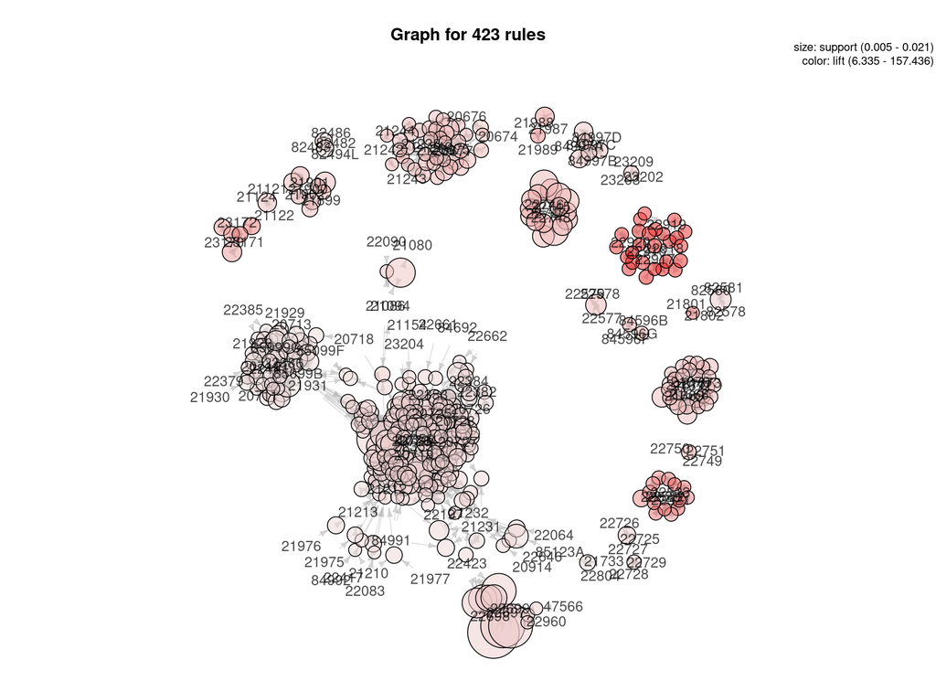

```r
apriori_rules_tg <- basket_apriori %>%
  plot(
    method  = "graph",
    control = list(max = 1000)
    ) %>%
  as("igraph") %>%
  as_tbl_graph()
```

```r
apriori_rules_tg %>% glimpse()
```

[output not shown]